# Biking through (the data) life(cycle)

#### Exploring bikesharing trends from 2015 with Sarah Otis

[figure not shown]

Source: [Cmsc320, Fall 2018 course website](https://www.cs.umd.edu/class/fall2018/cmsc320/)

## Introduction

If you liked biking, which would you rather: a bike of your own, or a bikeshare membership? A bike, which requires maintenance and protection from theft or rust, gives you the freedom to go for long rides, park wherever you like, and leave the city for some scenic trails. But, it's not easily transportable to other cities, and you may not be able to afford to buy a lasting bike or have space for one. What would push you to join a bikeshare program? If nothing would, would you still use bikeshares as a way to get around once or twice a year for $3?

In 2015, Chicago's bikeshare program Divvy, began serving the largest area in North America. They updated their pricing plans, too, and began to advertise to low-income riders. By 2015, Divvybikes were only two years old. Divvy has released its trip data from 2013 through today, and we are invited to find out more about the history of this bikeshare program. What can we learn from Divvy's 2015 data?

Ready? Let's prepare for our journey!

## Preparing for the road: Imports

Before we get started, we must make sure to import all necessary packages and libraries. Numpy and pandas are our fundamental library. Pandas, numpy, matplotlib, and seaborn all help us with basic data visualization. Sklearn is a robust library of tools to help with regression analysis and machine learning. Missingno will help us visualize missing data, but we first need to install the package (it is not included by default in the language). To mute the output of this install, we write the output to a different location with `>/dev/null 2>&1`. Regex will help us choose content from columns.

```python
import pandas as pd
import numpy
import seaborn as sns
import matplotlib.pyplot as plt
import datetime
from sklearn import datasets, linear_model
from sklearn.model_selection import train_test_split
!pip install missingno >/dev/null 2>&1
import missingno as msno
import re
```

## Destination #1: Data Collection

We have a handful of datasets: our trips dataset, and our station dataset, and a weather dataset. Let us load and view our data.

#### Divvybike Trips Dataset, from [Divvybikes.com](https://www.divvybikes.com/system-data)

```python
_2015Q1 = pd.read_csv("Divvy_Trips_2015-Q1.csv")
# _2015Q2 = pd.read_csv("Divvy_Trips_2015-Q2.csv") - we are excluding some datasets for now because this computer
# _201507 = pd.read_csv("Divvy_Trips_2015_07.csv")   can handle only so much processing at once. Please uncomment
# _201508 = pd.read_csv("Divvy_Trips_2015_08.csv")   these lines for more data and potentially different, more
# _201509 = pd.read_csv("Divvy_Trips_2015_09.csv")   intriguing results!
# _2015Q4 = pd.read_csv("Divvy_Trips_2015_Q4.csv")


# chicago_bikeshare_data = pd.concat([_2015Q1, _2015Q2, _201507, _201508, _201509, _2015Q4])
chicago_bikeshare_data = pd.concat([_2015Q1])
print (chicago_bikeshare_data.shape)
chicago_bikeshare_data.head()
```

```
(202349, 12)
```

|  | trip_id | starttime | stoptime | bikeid | tripduration | from_station_id | from_station_name | to_station_id | to_station_name | usertype | gender | birthyear |
| --- | --- | --- | --- | --- | --- | --- | --- | --- | --- | --- | --- | --- |
| 0 | 4738454 | 3/31/2015 23:58 | 4/1/2015 0:03 | 1095 | 299 | 117 | Wilton Ave & Belmont Ave | 300 | Broadway & Barry Ave | Subscriber | Male | 1994.0 |
| 1 | 4738450 | 3/31/2015 23:59 | 4/1/2015 0:15 | 537 | 940 | 43 | Michigan Ave & Washington St | 85 | Michigan Ave & Oak St | Customer | NaN | NaN |
| 2 | 4738449 | 3/31/2015 23:59 | 4/1/2015 0:11 | 2350 | 751 | 162 | Damen Ave & Wellington Ave | 67 | Sheffield Ave & Fullerton Ave | Subscriber | Male | 1992.0 |
| 3 | 4738448 | 3/31/2015 23:59 | 4/1/2015 0:19 | 938 | 1240 | 51 | Clark St & Randolph St | 59 | Wabash Ave & Roosevelt Rd | Customer | NaN | NaN |
| 4 | 4738445 | 3/31/2015 23:54 | 4/1/2015 0:15 | 379 | 1292 | 134 | Peoria St & Jackson Blvd | 216 | California Ave & Division St | Subscriber | Male | 1976.0 |

Our dataset comes with a row for each Divvybike trip. Each row contains trip id, bike id, from- and to- station ids and names, start and stop times in datetime format, trip durations, and user data like whether they are a subscriber (=have an annual membership) or whether they are a customer (=are a casual user without a membership), their gender, and their birthyear. It is worth noting that tripdurations are measured in seconds.

#### Adding geolocation data with Divvybike stations dataset, also from [Divvybikes.com](https://www.divvybikes.com/system-data)

We have station names and id numbers already - these attributes will help us study categorical data if we'd like! We add a column to this dataset with geolocations (latitude and longitude) of each station to allow us to study the approximate distances of trips, altitudes of stations, and locations of bikes. Below, we load in the Divvy station geolocations and add them as a column to our main bikeshare dataset:

```python
_stations2015 = pd.read_csv("Divvy_Stations_2015.csv")
_stations2015.head()
```

|  | id | name | latitude | longitude | dpcapacity | landmark |
| --- | --- | --- | --- | --- | --- | --- |
| 0 | 2 | Michigan Ave & Balbo Ave | 41.872293 | -87.624091 | 35 | 541 |
| 1 | 3 | Shedd Aquarium | 41.867226 | -87.615355 | 31 | 544 |
| 2 | 4 | Burnham Harbor | 41.856268 | -87.613348 | 23 | 545 |
| 3 | 5 | State St & Harrison St | 41.874053 | -87.627716 | 23 | 30 |
| 4 | 6 | Dusable Harbor | 41.885042 | -87.612795 | 31 | 548 |

#### What About Weather? Adding a [Kaggle](https://www.kaggle.com/selfishgene/historical-hourly-weather-data) weather dataset

This dataset from Kaggle contains hourly categorical weather data for the City of Chicago from 2012 to 2017. We are interested in the data from 2015.

```python
import warnings
warnings.filterwarnings('ignore')

_weather = pd.read_csv("weather_description.csv", sep=',')
_weather = (_weather[_weather['datetime'].str.contains(r'^2015-0(1|2|3|4)')])
weather2015 = pd.DataFrame({'datetime': _weather['datetime'], 'weather': _weather['Chicago']})
weather2015.head()
```

|  | datetime | weather |
| --- | --- | --- |
| 19716 | 2015-01-01 00:00:00 | sky is clear |
| 19717 | 2015-01-01 01:00:00 | sky is clear |
| 19718 | 2015-01-01 02:00:00 | sky is clear |
| 19719 | 2015-01-01 03:00:00 | sky is clear |
| 19720 | 2015-01-01 04:00:00 | sky is clear |

## Destination #2: Tidy Data

#### Combine divvybike datasets

```python
# Adding geolocations for starting points
_stations2015 = _stations2015.drop(['landmark'], axis=1).rename(index=str,
                                                                columns={"name": "from_station_name",
                                                                         "latitude": "from_latitude",
                                                                         "longitude": "from_longitude",
                                                                         "dpcapacity": "from_dpcapacity"})
chicago_bikeshare_data = pd.merge(chicago_bikeshare_data,
                 _stations2015[['from_station_name', 'from_latitude', 'from_longitude', 'from_dpcapacity']],
                 on='from_station_name', how='left')

# Adding geolocations for ending points
_stations2015 = _stations2015.rename(index=str, columns={"from_station_name":"to_station_name",
                                                         "from_latitude":"to_latitude",
                                                         "from_longitude": "to_longitude",
                                                         "from_dpcapacity": "to_dpcapacity"})
chicago_bikeshare_data = pd.merge(chicago_bikeshare_data,
                 _stations2015[['to_station_name', 'to_latitude', 'to_longitude', 'to_dpcapacity']],
                 on='to_station_name', how='left')

print (chicago_bikeshare_data.shape)
chicago_bikeshare_data.head()
```

```
(202349, 18)
```

|  | trip_id | starttime | stoptime | bikeid | tripduration | from_station_id | from_station_name | to_station_id | to_station_name | usertype | gender | birthyear | from_latitude | from_longitude | from_dpcapacity | to_latitude | to_longitude | to_dpcapacity |
| --- | --- | --- | --- | --- | --- | --- | --- | --- | --- | --- | --- | --- | --- | --- | --- | --- | --- | --- |
| 0 | 4738454 | 3/31/2015 23:58 | 4/1/2015 0:03 | 1095 | 299 | 117 | Wilton Ave & Belmont Ave | 300 | Broadway & Barry Ave | Subscriber | Male | 1994.0 | 41.940180 | -87.653040 | 23 | 41.937725 | -87.644095 | 19 |
| 1 | 4738450 | 3/31/2015 23:59 | 4/1/2015 0:15 | 537 | 940 | 43 | Michigan Ave & Washington St | 85 | Michigan Ave & Oak St | Customer | NaN | NaN | 41.883893 | -87.624649 | 43 | 41.900960 | -87.623777 | 23 |
| 2 | 4738449 | 3/31/2015 23:59 | 4/1/2015 0:11 | 2350 | 751 | 162 | Damen Ave & Wellington Ave | 67 | Sheffield Ave & Fullerton Ave | Subscriber | Male | 1992.0 | 41.935880 | -87.678420 | 15 | 41.925602 | -87.653708 | 15 |
| 3 | 4738448 | 3/31/2015 23:59 | 4/1/2015 0:19 | 938 | 1240 | 51 | Clark St & Randolph St | 59 | Wabash Ave & Roosevelt Rd | Customer | NaN | NaN | 41.884576 | -87.631890 | 31 | 41.867227 | -87.625961 | 23 |
| 4 | 4738445 | 3/31/2015 23:54 | 4/1/2015 0:15 | 379 | 1292 | 134 | Peoria St & Jackson Blvd | 216 | California Ave & Division St | Subscriber | Male | 1976.0 | 41.877749 | -87.649633 | 19 | 41.903029 | -87.697474 | 15 |

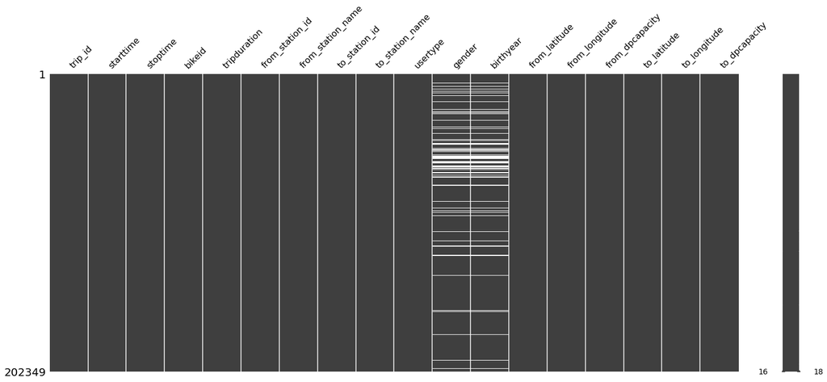

```python
%matplotlib inline
display(msno.matrix(chicago_bikeshare_data))
```

```python
print ("Total missing cols: " + str(len(chicago_bikeshare_data) - chicago_bikeshare_data.dropna().shape[0]))
print ("Cols missing gender: " + str(len(chicago_bikeshare_data)
                                     - chicago_bikeshare_data.drop('gender', axis=1).dropna().shape[0]))
print ("Cols missing birthyear: " + str(len(chicago_bikeshare_data)
                                    - chicago_bikeshare_data.drop('gender', axis=1).dropna().shape[0]))
print ()
print ("Rows with missing data from customers: " + str(len((chicago_bikeshare_data[chicago_bikeshare_data['birthyear'].isnull()])[chicago_bikeshare_data[
    'usertype'] == 'Customer'])))
print ("Rows with missing data from subscribers: " + str(len((chicago_bikeshare_data[chicago_bikeshare_data['birthyear'].isnull()])[chicago_bikeshare_data[
    'usertype'] == 'Subscriber'])))
```

```
Total missing cols: 24491
Cols missing gender: 24491
Cols missing birthyear: 24491

Rows with missing data from customers: 24491
Rows with missing data from subscribers: 0
```

All customer (casual or one-time user) data is missing gender and birthyear. This only means that Divvybike does not require actual registration for one-time users, and subscribers (Divvybike members) must provide this information upon registration; this data is missing not at random (MNAR). Since this is a significant portion of our dataset, we will revisit the missing data later on.

#### Eliminate outliers in user data

The gender and birthyear atrributes are giving us the most trouble, and Divvybike offers no race, income, or lifestyle data. Still, if gender and birthyear enter our analysis later, we will thank ourselves for having tidied the data now.

According to the [US Census Bureau](https://factfinder.census.gov/faces/tableservices/jsf/pages/productview.xhtml?src=CF), approximately 1.4% of the population each year since 2015 has been 85 or older. We can safely discount all these ages without significantly affecting our birthyear statistics for bikeshare riders. More statistically speaking, we can discount all ages that are beyond the "99.7%" of data that the 3-sigma rule describes. Below, we set [outliers](https://www.kdnuggets.com/2017/02/removing-outliers-standard-deviation-python.html) of our lower bound, which are below `mean - 3*SD`, to null.

```python
def eliminate_outliers(series):
    lower_bound = series.mean()-3*series.std()
#     upper_bound = series.mean()+2*series.std()

    return [(val if val >= lower_bound else None) for val in series]
#     return [(val if (val <= upper_bound and val >= lower_bound) else None) for val in series]

display(chicago_bikeshare_data['birthyear'].describe())
chicago_bikeshare_data['birthyear'] = eliminate_outliers(chicago_bikeshare_data['birthyear'])
display(chicago_bikeshare_data['birthyear'].describe())
```

```
count    177858.000000
mean       1977.813745
std          10.724572
min        1900.000000
25%        1971.000000
50%        1981.000000
75%        1986.000000
max        1998.000000
Name: birthyear, dtype: float64
```

```
count    177384.000000
mean       1977.917941
std          10.527771
min        1946.000000
25%        1971.000000
50%        1981.000000
75%        1986.000000
max        1998.000000
Name: birthyear, dtype: float64
```

#### Standardizing datetime columns

We are aggregating lots of trip data and combining multiple datasets, so units should reflect standard formatting. People like to be creative with datetime formats, so let us write a method to standardize datetime to [ISO 8601 extended formats](https://en.wikipedia.org/wiki/ISO_8601) for any column. We will standardize the `chicago_bikeshare_data` immediately. We will also add in an hourly datetime column for convenience merging hourly weather data.

```python
DATETIME_MINUTES_INDEX = 14

def datetime_standard(dtime):
    prog = re.compile(r'^2015-')
    result = prog.match(dtime)
    if result:
        dtime = datetime.datetime.strptime(dtime,'%Y-%m-%d %H:%M:%S')
    else:
        dtime = datetime.datetime.strptime(dtime,'%m/%d/%Y %H:%M')
    return dtime.strftime('%Y-%m-%d %H:%M:%S')

# Re-formatting datetime columns
chicago_bikeshare_data['starttime'] = [datetime_standard(d) for d in chicago_bikeshare_data.starttime]
chicago_bikeshare_data['stoptime'] = [datetime_standard(d) for d in chicago_bikeshare_data.stoptime]
chicago_bikeshare_data['datetime'] = [(d[:DATETIME_MINUTES_INDEX] + '00:00') for d in chicago_bikeshare_data.starttime]
```

#### Tidy & add weather data

```python
# Checks for missing values.
%matplotlib inline
display(weather2015.info())
```

```
<class 'pandas.core.frame.DataFrame'>
Int64Index: 2880 entries, 19716 to 22595
Data columns (total 2 columns):
datetime    2880 non-null object
weather     2880 non-null object
dtypes: object(2)
memory usage: 67.5+ KB
```

```
None
```

What are the different types of weather that visit Chicago? If you are following along with this tutorial in your own Jupyter notebook, peek at the different types of weather with `groupby('weather').groups.keys()`. Once you have done that, take a look at how to create a simple dataframe to reflect the frequency of each weather type and to assign relative safeties to different weather types for bikers. We will revisit this soon.

```python
# Adding weather classification for safety (categorical) and risk  #
# index (numerical representation) to dataset for easier analysis: #
def classify_weather(wtype):
    safe = ['broken clouds', 'few clouds', 'overcast clouds', 'proximity thunderstorm', 'scattered clouds',
                'sky is clear']
    mediocre = ['drizzle', 'fog', 'haze', 'light intensity drizzle', 'light snow', 'mist',
                'proximity shower rain', 'proximity thunderstorm with drizzle', 'smoke',
                'thunderstorm with light drizzle']
    dangerous = ['dust', 'freezing rain', 'heavy intensity drizzle', 'heavy intensity rain', 'heavy snow',
                'light rain', 'moderate rain', 'proximity thunderstorm with rain', 'snow', 'squalls',
                'thunderstorm with heavy rain', 'thunderstorm with rain','thunderstorm with light rain',
                'very heavy rain']
    return 'safe' if wtype in safe else ('mediocre' if wtype in mediocre else 'dangerous')

def risk_index(safety):
    if safety == "safe":
        return 0
    elif safety == "mediocre":
        return .5
    elif safety == "dangerous":
        return 1
    else:
        return None

# Adding columns of interest to weather dataframe
weather2015['safety'] = [(classify_weather(item)) for item in weather2015.weather]
weather2015['risk_index'] = [(risk_index(item)) for item in weather2015.safety]

# Re-formatting datetime column
weather2015['datetime'] = [datetime_standard(d) for d in weather2015.datetime]

# Adding categorical weather data for starting points to main bikeshare dataframe
chicago_bikeshare_data = pd.merge(chicago_bikeshare_data,
                 weather2015[[ 'datetime', 'weather', 'safety', 'risk_index']],
                 on='datetime', how='left')
```

#### Mean imputation on missing bikeshare data

One more thing before we begin to explore.

In order to fill in missing data, we will perform mean imputation by replacing null values with the mean value of each column. Below, we mean impute data and confirm that all columns are complete after the tidying we have done.

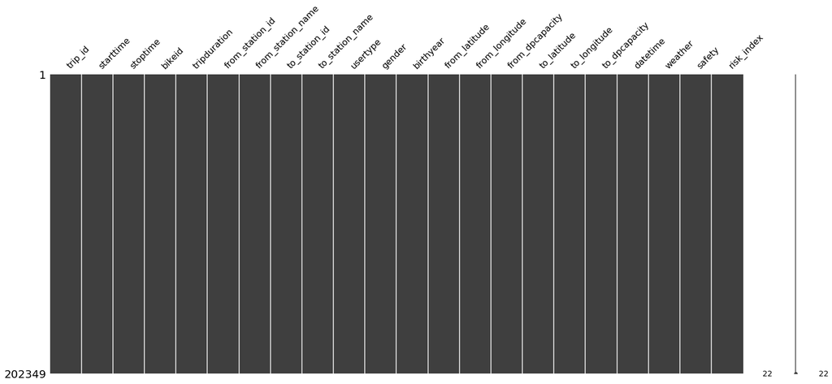

```python
# Assigning numerical vals to gender for mean, and imputing
temp = chicago_bikeshare_data.dropna(subset=['gender'])
gender = {'Male': 0,'Female': 1}
temp['gender_id'] = [gender[item] for item in temp.gender] #assign numerical values to gender for describe()
if temp['gender_id'].mean() < .5 and temp['gender_id'].median() == 0:
    chicago_bikeshare_data['gender'] = chicago_bikeshare_data['gender'].fillna('Male')
else: # this can be improved in the future
    chicago_bikeshare_data['gender'] = chicago_bikeshare_data['gender'].fillna('Male')

# Imputing for birthyears
chicago_bikeshare_data['birthyear'] = chicago_bikeshare_data['birthyear'].fillna(
                                                                      chicago_bikeshare_data['birthyear'].mean())

# Confirming that data from weather2015 has properly merged and gender/birthyear were properly imputed
display(msno.matrix(chicago_bikeshare_data))
```

```
                                       A complete dataset!
```

## Destination #3: Exploratory Data Analysis

Until now, we've been on a straight path. Collect the data, tidy the data, and now... do something with the data? Let us take some detours to explore which street we'd like to take next with our data! We want to arrive at a meaningful destination, so we try to gain as much as possible from our data before pedaling more through our data lifecycle. Let us explore basic information about our data.

We can ask so many questions about our data. What can we learn about its inventory, about popular trip times, about users, about geolocations? For now, let us stick to one theme: distance.

Distance in our dataset may be studied from a variety of perspectives:

1. How far, on average, do people travel each day?
2. Do distances peak at different times of the day? Can we predict any trends about distance based on time of day?
3. Do people of different ages travel different distances?
4. Do a higher percentage of subscribers or customers travel longer distances?
5. How does weather affect distance? If weather affects distance, does this vary by time of day, usertype, or season?
6. Is there any way we can track bikes to see whether bikes that are used a certain number of times begin to be used less? Or, for shorter distances? Or, during bad weather they are used for shorter distances?
7. Are there certain locations from which riders take longer trips? Tangentially, can we learn anything about popular places in Chicago based on this distance data?

We will attempt to answer the first of these questions together. In the future, we look at certain other surface-level aspects of our dataset, and then pedal into a deeper exploration of our data.

[figure not shown]

```
                                       The Exploratorium, San Francisco
```

#### Basic information: the bikeshare dataset

`dataframe.describe()` tells us some basic stats on our dataset. We drop most categorical numbers for this. We add boolean numbers or numerical indexes for categorical variables to study their ratios.

```python
import warnings
warnings.filterwarnings('ignore')

temp = chicago_bikeshare_data.dropna(subset=['gender'])
gender = {'Male': 0,'Female': 1}
temp['gender_id'] = [gender[item] for item in temp.gender] #assign numerical values to gender for describe()
display(temp.describe().drop(['from_station_id', 'to_station_id','trip_id', 'bikeid', 'from_latitude',
                                       'from_longitude', 'to_latitude', 'to_longitude'], axis=1))
print("Median user birthyear: " + str(chicago_bikeshare_data['birthyear'].median()))
print("Median dock capacity per trip origin: " + str(chicago_bikeshare_data['from_dpcapacity'].median()))
print("Median dock capacity per trip destination: " + str(chicago_bikeshare_data['to_dpcapacity'].median()))
print("Median trip duration: " + str(chicago_bikeshare_data['tripduration'].median()/60) + " minutes")
```

|  | tripduration | birthyear | from_dpcapacity | to_dpcapacity | risk_index | gender_id |
| --- | --- | --- | --- | --- | --- | --- |
| count | 202349.000000 | 202349.000000 | 202349.000000 | 202349.000000 | 202349.000000 | 202349.000000 |
| mean | 785.447667 | 1977.917941 | 21.401119 | 21.408161 | 0.149410 | 0.163999 |
| std | 2068.399468 | 9.856960 | 7.187096 | 7.222092 | 0.327597 | 0.370275 |
| min | 60.000000 | 1946.000000 | 11.000000 | 11.000000 | 0.000000 | 0.000000 |
| 25% | 334.000000 | 1973.000000 | 15.000000 | 15.000000 | 0.000000 | 0.000000 |
| 50% | 542.000000 | 1979.000000 | 19.000000 | 19.000000 | 0.000000 | 0.000000 |
| 75% | 890.000000 | 1986.000000 | 27.000000 | 27.000000 | 0.000000 | 0.000000 |
| max | 85766.000000 | 1998.000000 | 43.000000 | 43.000000 | 1.000000 | 1.000000 |

```
Median user birthyear: 1979.0
Median dock capacity per trip origin: 19.0
Median dock capacity per trip destination: 19.0
Median trip duration: 9.03333333333 minutes
```

#### Extracting time information from starttime and appending to dataset for analysis

This will make trends more clear, as patterns will likely differ on the weekends.

```python
weekday_id = []
weekday = []
week = []
hour = []
workweek = []

for i in range(len(chicago_bikeshare_data)):
    dtime = chicago_bikeshare_data.iloc[i]['starttime']
    dtime = datetime.datetime.strptime(dtime,'%Y-%m-%d %H:%M:%S')

    weekdays = ['sunday','monday','tuesday','wednesday','thursday','friday','saturday']
    wkdy_id = (dtime.timetuple().tm_wday + 1) % 7

    weekday_id.append(wkdy_id)
    weekday.append(weekdays[wkdy_id]) # 0 is Monday in documentation, so 1 is Sunday now
    week.append(dtime.isocalendar()[1])
    hour.append(dtime.timetuple().tm_hour)
    workweek.append('y' if (wkdy_id > 0 and wkdy_id < 6) else 'n')

# Add all the temp data from datetime format to main dataset through full join
temp = pd.DataFrame({'week': week, 'weekday': weekday,'weekday_id':weekday_id, 'hour':hour,
                     'workweek': workweek, 'starttime': chicago_bikeshare_data['starttime']})
chicago_bikeshare_data = pd.merge(chicago_bikeshare_data, temp[['week', 'weekday','weekday_id', 'hour',
                     'workweek', 'starttime']], on='starttime', how='left')
```

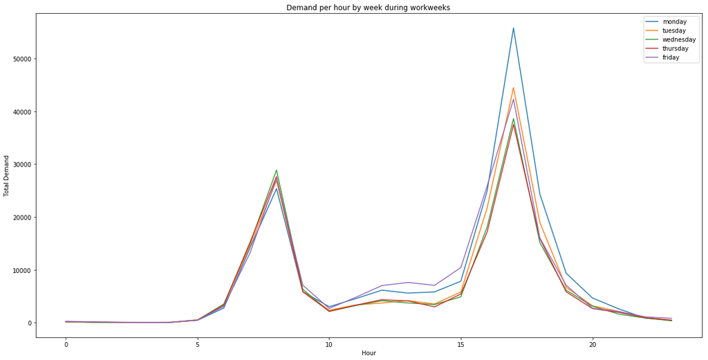

```python
plt.figure(figsize=(20, 10))
for z in ['monday', 'tuesday','wednesday','thursday','friday']:
    hourly_demand_weekday = {}
    wkdy = chicago_bikeshare_data[chicago_bikeshare_data['weekday']==z]
    for x in wkdy.groupby('hour').groups.keys():
        hourly_demand_weekday[x] = len(wkdy[wkdy['hour']==x])
    myplot = plt.plot(hourly_demand_weekday.keys(), hourly_demand_weekday.values(), label=z)
    plt.legend()
    plt.xlabel("Hour")
    plt.ylabel("Total Demand")
    plt.title("Demand per hour by week during workweeks")
plt.show()
```

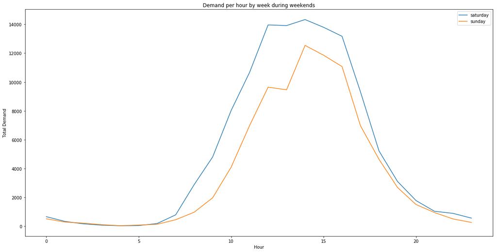

```python
plt.figure(figsize=(20, 10))
for z in ['saturday', 'sunday']:
    hourly_demand_weekend = {}
    wkdy = chicago_bikeshare_data[chicago_bikeshare_data['weekday']==z]
    for x in wkdy.groupby('hour').groups.keys():
        hourly_demand_weekend[x] = len(wkdy[wkdy['hour']==x])
    myplot = plt.plot(hourly_demand_weekend.keys(), hourly_demand_weekend.values(), label=z)
    plt.legend()
    plt.xlabel("Hour")
    plt.ylabel("Total Demand")
    plt.title("Demand per hour by week during weekends")
for x in wkdy.groupby('hour').groups.keys():
        hourly_demand_weekend[x] = len(wkdy[wkdy['hour']==x])

plt.show()
```

#### Weather data

Let's take a look at weather trends. With our original weather dataset, we will visualize the frequency of safe, mediocre, and dangerous weather in a pie chart. This will help us begin to explore our data.

```python
# See notes on weather classification, below
freq = {}
weather_type = {}

# Assigning categorical safety value
for x in weather2015.groupby('weather').groups.keys():
    weather_type[x] = x
    freq[x] = len(weather2015.loc[weather2015['weather'] == x])
weather_freq = pd.DataFrame({'weather_type': weather_type,
                             'frequency2015': freq}).reset_index().drop(['index'],axis =1)
weather_freq['safety'] = [(classify_weather(item)) for item in weather_freq.weather_type]
weather_freq.head()
```

|  | weather_type | frequency2015 | safety |
| --- | --- | --- | --- |
| 0 | broken clouds | 326 | safe |
| 1 | few clouds | 248 | safe |
| 2 | heavy intensity rain | 34 | dangerous |
| 3 | heavy snow | 9 | dangerous |
| 4 | light rain | 167 | dangerous |

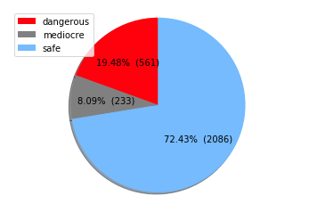

```python
# Pie chart for weather safety!
def make_autopct(values):
    def my_autopct(pct):
        total = sum(values)
        val = int(round(pct*total/100.0))
        return '{p:.2f}%  ({v:d})'.format(p=pct,v=val)
    return my_autopct

weather_safety = {}
for x in weather_freq.groupby('safety').groups.keys():
    weather_safety[x] = weather_freq[weather_freq['safety'] == x].sum().frequency2015

colors = ['xkcd:bright red','gray','xkcd:sky blue']
patches, texts, y = plt.pie(weather_safety.values(), colors=colors, shadow=True, startangle=90,
                            autopct=make_autopct(weather_safety.values()))
plt.legend(patches, weather_safety.keys(), loc = 'upper left')
plt.axis('equal')
plt.figure(figsize=(15, 15))
plt.show()
```

Tip: if a color doesn't exist, try putting `xkcd:` before the rest of the color name.

#### Distance

We have some basic knowledge of weather and bikeshare demand up our sleeves now. And, we have a basic idea of how to plot and to look at ratios. How ready do we feel to explore a question? Let's head down our first route:

#### How far do people travel each day?

First, let us take a look at a plot of median tripduration per hour each day during the workweek.

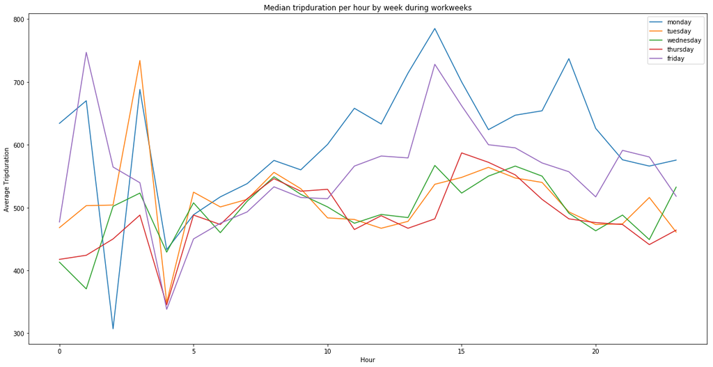

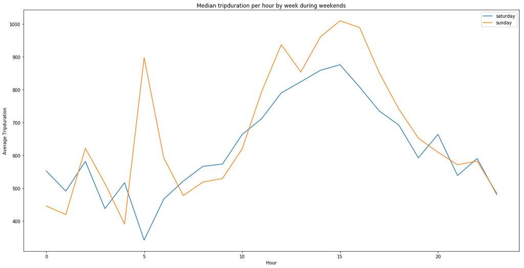

```python
plt.figure(figsize=(20, 10))
for z in ['monday', 'tuesday','wednesday','thursday','friday']:
    avg_dist_hourly_wkday = {}
    wkdy = chicago_bikeshare_data[chicago_bikeshare_data['weekday']==z]
    for x in wkdy.groupby('hour').groups.keys():
        avg_dist_hourly_wkday[x] = (wkdy[wkdy['hour']==x]).tripduration.median()
    myplot = plt.plot(avg_dist_hourly_wkday.keys(), avg_dist_hourly_wkday.values(), label=z)
    plt.legend()
    plt.xlabel("Hour")
    plt.ylabel("Average Tripduration")
    plt.title("Median tripduration per hour by week during workweeks")
plt.show()

plt.figure(figsize=(20, 10))
for z in ['saturday', 'sunday']:
    avg_dist_hourly_wkend = {}
    wkdy = chicago_bikeshare_data[chicago_bikeshare_data['weekday']==z]
    for x in wkdy.groupby('hour').groups.keys():
        avg_dist_hourly_wkend[x] = (wkdy[wkdy['hour']==x]).tripduration.median()
    myplot = plt.plot(avg_dist_hourly_wkend.keys(), avg_dist_hourly_wkend.values(), label=z)
    plt.legend()
    plt.xlabel("Hour")
    plt.ylabel("Average Tripduration")
    plt.title("Median tripduration per hour by week during weekends")
plt.show()
```

## Destination #4: Analysis, Hypothesis Testing, and ML

[output not shown]

[figure not shown]

```
             Before now, the paths after the fork in the road seemed more difficult to choose
             between. Data can help us make insight and policy decisions. Image source: Alicia Tatone
```

## Conclusion

Thank you for reading this tutorial. I hope you have learned something. If you have questions, please contact me!

The analysis in this tutorial is in no way perfect. The data augmented to the bikeshare data is also in now way perfect. Maybe I will follow up with another tutorial using more robust data from NOAA or data as robust as meteoblue (which is, unfortunately, not free), and I can compare the results of this tutorial's data to an analysis with more robust data. Maybe I will followup with an analysis on elevation data and compare to predictions with elevation benchmark data to predictions with more exact elevation or altitude data.

As you can see from the opening image of this tutorial, the data lifecycle involves a constant feedback loop. During the creation of this tutorial, I continuously re-evaluated the data I used, tidied data, explored different ideas with the data, and collected more data. Still, I try my best to distill the tutorial into five distinct parts. Anyone who applies the concepts of this tutorial to another dataset will learn that the feedback loops are inevitable. The back-and-forth of the data lifecycle makes data science feel like a good book. Where will the data take us next? What will we discover?

#### Questions to consider about bikesharing data

- Do riders go the same distances at different speeds, on average, based on different peak times of the day?
- Does elevation in Chicago affect the direction of travel? Is there a higher demand for and a shortage of bikes at elevated docks, and a lower demand and surplus of bikes at lower elevation docks? (Who are we kidding? This is the flat Midwest.)
- Why so many men in their 30s? What is their race and their occupation? What motivates them over other demographics to choose the Divvybike commute?
- Does weather affect demand for rides? Specifically, can we compare categorical precipitation and weather data to bike demand for any meaningful results?
- Are there less rides during and after bad weather, or just during bad weather? (How tough are Chicagoans?) How fast do bikeshare riders return to the streets?
- What kinds of inventory analysis can be done on this dataset? What insight and policy decisions might come of that?
- Are the rides that occur during bad weather shorter, on average?
- (Bonus:) Is there a way to tell how much tourists contribute to the user base? If so, during what seasons, and since there are so many other modes of transportation--subway, Metra, water taxi, Uber, walking, etc.--where do they mostly prefer to ride with their bikes?
- At what times of the day is bike demand the highest; when is bike demand at its lowest?
- Is time of day a good predictor for trip duration?
- How accurate were Divvybike's predictions of station popularity (presumably) when they decided upon dock capacities? Is dock capacity a good predictor for bikeshare activity at each station?

Feel free to explore questions that draw your attention, and please share your results!